# King County Undervalued Property Analysis

## Problem Statement

This project explores whether a simple pricing model can help identify homes that appear underpriced relative to their estimated market value.

Instead of only asking, “What drives housing prices?”, I wanted to ask a more strategy-focused question:

**Which properties appear underpriced compared to what their features suggest they should be worth?**

The goal is to:

- Build a pricing benchmark model
- Compare predicted prices against actual sale prices
- Identify properties with large positive pricing gaps
- Treat the results as screening signals, not guaranteed investment opportunities

## Data Loading

**Purpose:** Load the King County housing dataset and confirm that the project can find the file from inside the project folder.

```r
library(tidyverse)
library(here)

housing <- read.csv(here("data", "kc_house_data.csv"))
```

**Code concept:**  
`library(tidyverse)` loads tools for data analysis and visualization.  
`library(here)` helps R find files reliably from the project folder.  
`read.csv()` imports the housing dataset into R as a dataframe called `housing`.

**Insight:**  
The dataset is now loaded into R and can be used to build a pricing model, compare predicted and actual sale prices, and identify possible mispricing patterns.

## Pricing Model

**Purpose:** Build a simple baseline model to estimate a home’s expected price based on key observable features.

```r
model <- lm(price ~ sqft_living + grade + bathrooms + view + waterfront, data = housing)
```

**Code concept:**  
`lm()` builds a linear regression model that estimates price as a combination of selected features.  
Each variable contributes independently to the predicted value.

**Why these features?**  
I focused on variables that are: - Intuitively important to pricing (size, quality, amenities) - Easy to interpret - Likely to capture a large portion of price variation

**Insight:**  
This model is not meant to be perfect — it acts as a **pricing benchmark**.  
The real value comes from comparing its predictions to actual sale prices.

## Identify Undervalued Properties

**Purpose:** Compare predicted prices to actual prices to identify homes that may be underpriced.

```r
# Predict prices
housing$predicted_price <- predict(model, newdata = housing)

# Calculate pricing gap
housing$price_difference <- housing$predicted_price - housing$price

# Sort by most undervalued
underpriced <- housing[order(-housing$price_difference), ]
```

**Code concept:**  
- `predict()` generates model-estimated prices  
- `price_difference` measures mispricing  
- Sorting highlights the largest positive gaps (predicted > actual)

## Top 10 Undervalued Opportunities

```r
top_underpriced <- underpriced[1:10, ]

top_underpriced[, c("price", "predicted_price", "price_difference",
                    "sqft_living", "grade", "view", "waterfront")]
```

```
##         price predicted_price price_difference sqft_living grade view
## 18849  380000         1588430        1208430.3        1980    10    4
## 8451   425000         1609148        1184148.3        3610     8    3
## 21051  900000         2021721        1121720.6        7120    12    4
## 8157   503000         1572740        1069739.9        2860     8    4
## 11557  357000         1394246        1037246.4        2460     7    4
## 4025   800000         1826907        1026906.6        7480    11    2
## 17475  540000         1503311         963311.2        2600     8    4
## 2714  1110000         2039292         929292.4        7350    11    4
## 8278   400000         1312374         912374.2        2090     7    4
## 9086   650000         1561883         911883.0        2800     8    4
##       waterfront
## 18849          1
## 8451           1
## 21051          0
## 8157           1
## 11557          1
## 4025           0
## 17475          1
## 2714           0
## 8278           1
## 9086           1
```

**Insight:**  
These properties represent the **largest gaps between estimated value and sale price**.

**Important:**  
These are **not guaranteed deals** — they are **signals for further investigation**.

## Visualization of Mispricing

**Purpose:** Visualize the relationship between predicted and actual prices to better understand model behavior and identify undervalued properties.

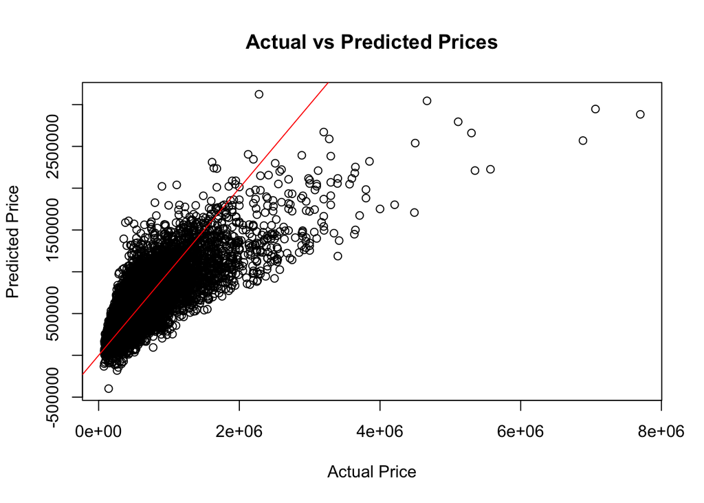

```r
plot(housing$price, housing$predicted_price,
     xlab = "Actual Price",
     ylab = "Predicted Price",
     main = "Actual vs Predicted Prices")

abline(0, 1, col = "red")
```

## Potentially Overpriced Properties

**Purpose:** Identify properties that may be overvalued relative to model expectations.

```r
overvalued <- housing[order(housing$price_difference), ]

head(overvalued[, c("price", "predicted_price", "price_difference",
                    "sqft_living", "grade", "view", "waterfront")])
```

```
##        price predicted_price price_difference sqft_living grade view waterfront
## 7253 7700000         2883303         -4816697       12050    13    3          0
## 9255 6885000         2569375         -4315625        9890    13    4          0
## 3915 7062500         2946921         -4115579       10040    11    2          1
## 4412 5570000         2226368         -3343632        9200    13    0          0
## 1449 5350000         2210798         -3139202        8000    12    4          0
## 8639 4489000         1708556         -2780444        6430    12    0          0
```

## Strategic Interpretation

**What the Model Reveals:**

The regression model captures key drivers of housing prices such as square footage, grade, and location-related features. With an R² of approximately 0.59, the model explains a meaningful portion of price variation, though not all.

**Undervalued Properties:**

Properties identified with large positive price differences (predicted > actual) may represent potential undervaluation. These properties appear to have characteristics that the market may not have fully priced in.

**Key Insight:**

**Important Limitation:**

This model does not capture all real-world factors such as: - Interior condition - Renovation quality - Market timing - Buyer/seller negotiation dynamics

Therefore, results should be interpreted as **signals**, not definitive investment opportunities.

**Strategic Use Case:**

This type of model could be used by: - Real estate investors to screen opportunities  
- Agents to identify pricing inefficiencies  
- Analysts to benchmark listing prices

### Decision Framing

This model is not designed to identify guaranteed investment opportunities, but rather to prioritize where deeper investigation should be focused. The strongest value comes from narrowing a large market into a smaller set of high-potential candidates. The key value is not predicting price perfectly, but identifying **relative mispricing patterns**.